# HW02-P1 Adv Data Viz

## Instructions

Using `ggplot2` and other tools in R, recreate the original New York Times graphic to the greatest extent possible. Try to get as close as possible to the figure below:

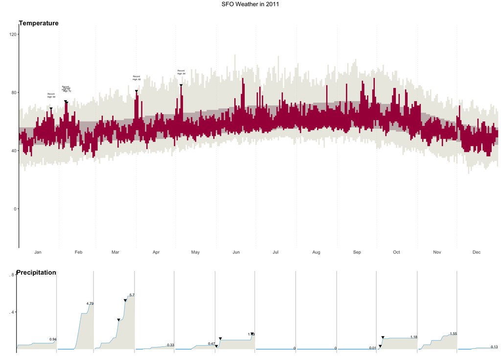

You will need to use reference pages and documentation to discover necessary tools. For example, you may want to Google search “ggplot multiple plots”. When looking through results, check publication dates and use newer references. Some helpful resources could include R documentation, Stack Overflow, and [R cheatsheets](https://rstudio.github.io/cheatsheets/).

**Requirements**

- Temperature graph
  - Bands for the record, normal, and actual highs and lows are shown in the correct colors.
  - Downward triangles point to the record high temperatures above the red band.
  - Text displays the record high temperatures above the triangles.
  - X-axis label: 3-letter month abbreviations appear in the middle of each month.
  - Y-axis label: Tick marks at 0, 40, 80, and 120 only.
  - Vertical lines separate the months.
  - Title of “Temperature” is included.
- Precipitation
  - Tan area and blue line reflecting the monthly cumulative precipitation is included.
  - Text (number) for cumulative precipitation for each month is included at the end of each month just above the blue line.
  - Downward triangles point to the record precipitation days.
  - Vertical lines separate the months.
  - Title of “Precipitation” is included.
- Overall
  - Both the temperature and precipitation graphs are in one figure.
  - The temperature plot takes up more vertical space than the precipitation plot.
  - The title “SFO weather in 2011” is present.
- Resource reflection
  - At least 1 resource is listed
  - At least 3 sentences about resources and their helpfulness in the task

**Bonus:** If you’d like further practice, recreate the legend in the temperature graph that shows how the colored lines relate to record, normal, and actual highs.

## Setup

```r
# Code for loading packages and reading in data
library(tidyverse)
library(patchwork)
weather <- read_csv("https://mac-stat.github.io/data/sfo_weather.csv")
```

## Visualization

```r
# Code for recreating the visualization
# Use as many code chunks as you need to organize your work well

# wrangling to create subsets for various geoms

# for vertical lines
first_days <- weather |>
  filter(dateInYear %in% c(32, 60, 91, 121, 152, 182, 213, 244, 274, 305, 335))
head(first_days)
```

```
# A tibble: 6 × 19
  Month   Day   Low  High NormalLow NormalHigh RecordLow LowYr RecordHigh HiYear
  <dbl> <dbl> <dbl> <dbl>     <dbl>      <dbl>     <dbl> <dbl>      <dbl>  <dbl>
1     2     1    45    63        44         58        30  1950         70   1976
2     3     1    40    59        46         60        35  1955         74   1959
3     4     1    54    78        47         63        37  1976         83   1959
4     5     1    47    76        49         66        44  2008         89   1947
5     6     1    51    62        52         68        43  1954         91   1989
6     7     1    54    80        54         71        46  1949         99   1985
# ℹ 9 more variables: Precip <dbl>, RecordPrecip <dbl>, PrecipYr <dbl>,
#   date <date>, dateInYear <dbl>, Record <lgl>, RecordText <chr>,
#   RecordP <lgl>, CulmPrec <dbl>
```

```r
# for month names on x-axis
middle_days <- c((1 + 15), # jan
                 (32 + 13.5), # feb
                 (60 + 15), # mar
                 (91 + 14.5), # apr
                 (121 + 15), # may
                 (152 + 14.5), # jun
                 (182 + 15), #jul
                 (213 + 15), # aug
                 (244 + 14.5), #sept
                 (274 + 15), # oct
                 (305 + 14.5), # nov
                 (335 + 15) # dec
                 )

# for record high triangles and text
record_highs <- weather |>
  filter(Record == TRUE)

# for record precipitation day triangles
record_precip <- weather |>
  filter(RecordP == TRUE)

# for last day of month minus dec (vert lines)
last_days <- weather |>
  filter(dateInYear %in% c(31, 59, 90, 120, 151, 181, 212, 243, 273, 304, 334))

# for monthly cuml precip total text
month_cuml_precip <- weather |>
  filter(dateInYear %in% c(31, 59, 90, 120, 151, 181, 212, 243, 273, 304, 334, 365))



# create monthly subsets (not efficient but it works; some sort of for loop or function would be better)

# jan
jan <- weather |>
  filter(Month == 1)

# feb
feb <- weather |>
  filter(Month == 2)

# mar
mar <- weather |>
  filter(Month == 3)

# apr
apr <- weather |>
  filter(Month == 4)

# may
may <- weather |>
  filter(Month == 5)

# jun
jun <- weather |>
  filter(Month == 6)

# jul
jul <- weather |>
  filter(Month == 7)

# aug
aug <- weather |>
  filter(Month == 8)

# sep
sep <- weather |>
  filter(Month == 9)

# oct
oct <- weather |>
  filter(Month == 10)

# nov
nov <- weather |>
  filter(Month == 11)

# dec
dec <- weather |>
  filter(Month == 12)
```

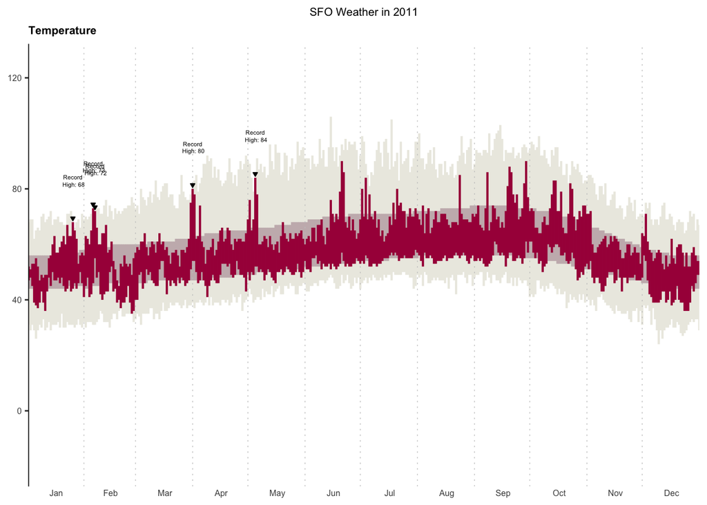

```r
# create temperature plot
temp_plot <- ggplot() +
  geom_linerange(data = weather,
                 aes(x = dateInYear, ymin = RecordLow, ymax = RecordHigh),
                 color = "#ECEBE3",
                 linewidth = 0.75) +
  geom_linerange(data = weather,
                 aes(x = dateInYear, ymin = NormalLow, ymax = NormalHigh),
                 color = "#C8B8BA",
                 linewidth = 0.75) +
  geom_vline(data = last_days,
             aes(xintercept = dateInYear),
             color = "#c7c7c7",
             linetype = 3,
             linewidth = 0.25) +
  geom_linerange(data = weather,
                 aes(x = dateInYear, ymin = Low, ymax = High),
                 color = "#A90248",
                 linewidth = 0.75) +
  geom_point(data = record_highs,
             aes(x = dateInYear, y = High + 1.4), # "+ 1.4" makes triangle bottom end at top of bar
             shape = 25,
             size = 0.75,
             fill = "black") +
  geom_text(data = record_highs,
            aes(x = dateInYear, y = High + 15, label = RecordText),
            size = 1.5,
            lineheight = 1) +
  scale_x_continuous(limits = c(1, 365),
                      expand = c(0,0),
                      breaks = middle_days,
                      labels = month.abb) +
  scale_y_continuous(limits = c(-20, 125)) +
  labs(title = "SFO Weather in 2011",
       subtitle = "Temperature") +
  theme(plot.title = element_text(size = 8,
                                  hjust = 0.5),
        plot.subtitle = element_text(size = 8,
                                  face = "bold",
                                  hjust = 0),
        axis.text.x = element_text(size = 6),
        axis.title.x = element_blank(),
        axis.ticks.x = element_blank(),
        axis.text.y = element_text(size = 6),
        axis.title.y = element_blank(),
        axis.line.y.left = element_line(color = "black",
                                        linewidth = 0.3),
        panel.background = element_blank())

temp_plot
```

```r
# add legend to temp_plot
temp_plot <- temp_plot +
  annotate("rect",
           xmin = 210.25, xmax = 212.25, ymin = -17, ymax = 7.5,
           fill = "#ECEBE3") +
  annotate("rect",
           xmin = 210.375, xmax = 212.125, ymin = -12, ymax = 3,
           fill = "#C8B8BA") +
  annotate("rect",
           xmin = 210.825, xmax = 211.675, ymin = -8.5, ymax = 5.5,
           fill = "#A90248") +
  annotate("segment",
           x = 211, xend = 215.575, y = 5.5, yend = 5.5,
           linewidth = 0.15) +
  annotate("segment",
           x = 211, xend = 215.575, y = -8.5, yend = -8.5,
           linewidth = 0.15) +
  annotate("segment",
           x = 207.25, xend = 209.225, y = 2.75, yend = 2.75,
           linewidth = 0.15) +
  annotate("segment",
           x = 207.25, xend = 209.225, y = -11.75, yend = -11.75,
           linewidth = 0.15) +
  annotate("segment",
           x = 207.25, xend = 207.25, y = -11.75, yend = 2.75,
           linewidth = 0.15) +
  annotate("text",
           x = 195, y = -5.25,
           size = 1.5,
           label = "Normal range") +
  annotate("text",
           x = 196, y = 7.5,
           size = 1.5,
           label = "Record high") +
  annotate("text",
           x = 196.75, y = -17.25,
           size = 1.5,
           label = "Record low") +
  annotate("text",
           x = 225, y = 5.5,
           size = 1.5,
           label = "Actual high") +
  annotate("text",
           x = 225, y = -8.5,
           size = 1.5,
           label = "Actual low")
```

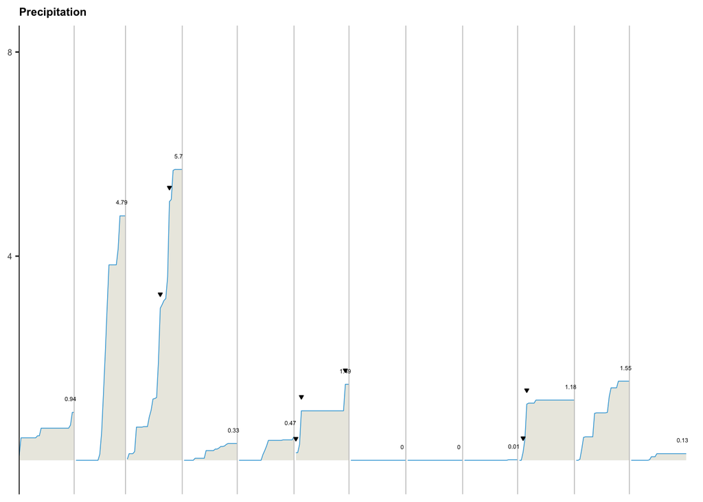

```r
# create precipitation plot
precip_plot <- ggplot() +
  geom_area(data = jan,
            aes(x = dateInYear, y = CulmPrec),
            fill = "#ebeae2",
            color = "#32a3d8",
            linewidth = 0.25) +
  geom_area(data = feb,
            aes(x = dateInYear, y = CulmPrec),
            fill = "#ebeae2",
            color = "#32a3d8",
            linewidth = 0.25) +
  geom_area(data = mar,
            aes(x = dateInYear, y = CulmPrec),
            fill = "#ebeae2",
            color = "#32a3d8",
            linewidth = 0.25) +
  geom_area(data = apr,
            aes(x = dateInYear, y = CulmPrec),
            fill = "#ebeae2",
            color = "#32a3d8",
            linewidth = 0.25) +
  geom_area(data = may,
            aes(x = dateInYear, y = CulmPrec),
            fill = "#ebeae2",
            color = "#32a3d8",
            linewidth = 0.25) +
  geom_area(data = jun,
            aes(x = dateInYear, y = CulmPrec),
            fill = "#ebeae2",
            color = "#32a3d8",
            linewidth = 0.25) +
  geom_area(data = jul,
            aes(x = dateInYear, y = CulmPrec),
            fill = "#ebeae2",
            color = "#32a3d8",
            linewidth = 0.25) +
  geom_area(data = aug,
            aes(x = dateInYear, y = CulmPrec),
            fill = "#ebeae2",
            color = "#32a3d8",
            linewidth = 0.25) +
  geom_area(data = sep,
            aes(x = dateInYear, y = CulmPrec),
            fill = "#ebeae2",
            color = "#32a3d8",
            linewidth = 0.25) +
  geom_area(data = oct,
            aes(x = dateInYear, y = CulmPrec),
            fill = "#ebeae2",
            color = "#32a3d8",
            linewidth = 0.25) +
  geom_area(data = nov,
            aes(x = dateInYear, y = CulmPrec),
            fill = "#ebeae2",
            color = "#32a3d8",
            linewidth = 0.25) +
  geom_area(data = dec,
            aes(x = dateInYear, y = CulmPrec),
            fill = "#ebeae2",
            color = "#32a3d8",
            linewidth = 0.25) +
  geom_vline(data = last_days,
             aes(xintercept = dateInYear),
             color = "#c7c7c7",
             linewidth = 0.3) +
  geom_point(data = record_precip,
             aes(x = dateInYear, y = CulmPrec + 0.275),
             shape = 25,
             size = 0.65,
             fill = "black") +
  geom_text(data = month_cuml_precip,
            aes(x = dateInYear - 2, y = CulmPrec + 0.265, label = CulmPrec),
            size = 1.5) +
  scale_x_continuous(limits = c(1, 370),
                      expand = c(0,0)) +
  scale_y_continuous(limits = c(-0.25, 8.1),
                     breaks = c(4, 8)) +
  labs(title = "Precipitation") +
  theme(plot.title = element_text(size = 8,
                                  face = "bold",
                                  hjust = 0),
        axis.text.x = element_blank(),
        axis.title.x = element_blank(),
        axis.ticks.x = element_blank(),
        axis.text.y = element_text(size = 6),
        axis.title.y = element_blank(),
        axis.line.y.left = element_line(color = "black",
                                        linewidth = 0.3),
        panel.background = element_blank())

precip_plot
```

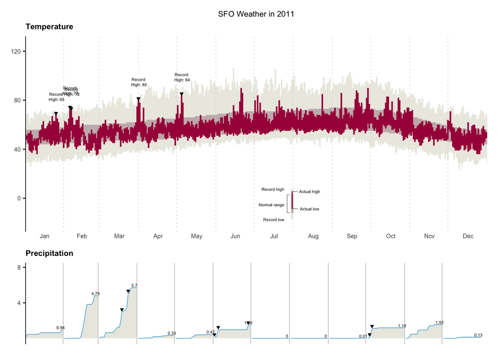

```r
# create full plot
full_plot <- temp_plot / precip_plot +
  plot_layout(nrow = 2, heights = c(3, 1.25))

full_plot
```

## Resources Reflection (required)

List the resources you used to help with this assignment then write 3-5 sentence reflection on which resources were most helpful in finishing this task.

**Resources:**

- Advanced Spatial Viz ICA
- https://ggplot2.tidyverse.org/reference/theme.html
- https://ggplot2-book.org/arranging-plots.html#arranging-plots-on-top-of-each-other
- https://ggplot2.tidyverse.org/reference/scale_continuous.html
- https://ggplot2.tidyverse.org/reference/annotate.html

**Reflection:**

The ggplot2 book was most helpful. It provided a good overview with some amount of detail for functions/geoms I needed to learn. The ggplot2 documentation was a good next step for reading about functions and their arguments in more detail. For example, I found the page about the theme() function and all of the arguments it takes incredibly helpful. I was able to customize the look of the plots with a fine level of control because there are so many options.